# Lab: p-values, GORIC(A), and Bayes factor

This lab material consists of multiple exercises and introduces (informative) hypothesis evaluation using p-values, the GORIC(A), and the Bayes factor.

## Exercise 1

### Data

All sub-exercises will be applied to the same data set: a simulated data set based on the Sesame Street data (Stevens, 1996), which is included as the dataset ‘sesamsim’ in the bain package. Thus, upon installing and loading the bain package, the sesamsim data set is automatically imported.

```r
# Install and load packages
#
# Install and load the bain library because it contains the data 'sesamesim'
if (!require("bain")) install.packages("bain") # install this package first (once)
library(bain)
#
if (!require("restriktor")) install.packages("restriktor") # install this package first (once)
library(restriktor) # for the function goric
#
if (!require("psych")) install.packages("psych") # install this package first (once)
library(psych) # for the function describeBy

# load the data set
data(sesamesim)
```

Since the exercises concern the effect of the children’s background on its increase in knowledge of numbers after watching Sesame street for one year, some data wrangling is required first. That is, a change score variable (i.e., the dependent variable) needs to be created, capturing the difference in knowledge after one year. To create the dependent variable, the children’s knowledge of numbers at baseline (prenumb) is subtracted from its knowledge of number after watching Sesame street for one year (postnumb):

```r
# create change score variable
sesamesim$post_pre <- sesamesim$postnumb - sesamesim$prenumb
```

In addition to the dependent variable, the grouping variable (site) needs to be transformed into a factor. The variable represents the background of a child and consists of 5 categories:

- disadvantaged inner city,
- advantaged suburban,
- advantaged rural,
- disadvantaged rural,
- disadvantaged Spanish speaking.

```r
# convert 'site' into a factor
sesamesim$site <- factor(sesamesim$site)
```

### Hypotheses

Assume that a group of researchers has come up with the following expectations:  
A. Children from a suburban advantaged background improve more than children from a rural one.  
B. Children from an advantaged background improve more than children from a disadvantaged background (for both 1. rural and 2. suburban).

More precisely:  
- A. In the advantaged suburban area (Group 2), the difference in knowledge of numbers is larger than in the advantaged rural area (Group 3):  
$\mu_2 > \mu_3$.  
- B1. In the advantaged rural area (Group 3), the difference in knowledge of numbers is larger than in the disadvantaged rural area (Group 4):  
$\mu_3 > \mu_4$.  
- B2. In the advantaged suburban region (Group 2), the difference in knowledge of numbers is larger than in the disadvantaged inner city (Group 1) and disadvantaged Spanish speaking area (Group 5):  
$\mu_2 > (\mu_1, \mu_5)$.

The researchers want to evaluate the combined expectations, that is, the following theory-based hypothesis:
$$H_1:
\mu_2 > \mu_3 > \mu_4, \mu_2 > (\mu_1, \mu_5),$$
that is,
$$H_1: \mu_2 > \mu_3 > \mu_4, \
\mu_2 > \mu_1, \ \mu_2 > \mu_5.$$

The goal of this exercise is to evaluate this hypothesis using a one-way ANOVA with `site` as the grouping variable and the newly created change score variable `post_pre` as the dependent variable.

### Exercise 1a: Classical Null Hypothesis Testing (NHT)

In this exercise, evaluate the aforementioned hypothesis using classical null hypothesis testing.

**Click to show answers**

```r
# Optional: Check descriptive statistics
head(sesamesim) # Look at first (6) rows of the data
```

```
##   sex site setting viewenc age peabody prenumb postnumb funumb Bb Bl Bf Bn Br
## 1   1    1       1       0  36      48      30       34      0 10 16  3 18  7
## 2   1    3       1       1  61      28      24       31      0  8  7  2  7  7
## 3   1    4       1       0  44      54      10       19      1 21  4 11 21  9
## 4   1    3       1       1  40      20       3        3      2 16 21  8 20  8
## 5   1    1       1       0  43      43      19       25      5 14 13  8  1 11
## 6   1    1       2       0  55      30      24       26      6 21  8 13 23 13
##   Bc Ab Al Af An Ar Ac post_pre
## 1  8 22 18 11 27  9 13        4
## 2  4 14  2  9 14 10  9        7
## 3  9 34 36 22 17 11 13        9
## 4  5 26 28 17 32 15 18        0
## 5 10 22  7 10 10 10  9        6
## 6 16 28 37 15 41 14 21        2
```

```r
describeBy(sesamesim$post_pre, sesamesim$site, mat=TRUE) # obtain descriptives by group
```

```
##     item group1 vars  n      mean        sd median   trimmed     mad min max
## X11    1      1    1 60  5.783333  8.328207    5.0  5.770833  7.4130 -17  30
## X12    2      2    1 55 12.636364 11.005661   12.0 12.911111 10.3782 -24  32
## X13    3      3    1 64  8.718750  7.818311    9.5  8.788462  6.6717  -8  29
## X14    4      4    1 43  6.883721 10.270645    7.0  7.371429 10.3782 -21  23
## X15    5      5    1 18 10.555556  8.318811   11.0 11.062500  5.9304 -11  24
##     range        skew    kurtosis        se
## X11    47  0.10322321  0.36054880 1.0751670
## X12    56 -0.44957553  0.59529385 1.4840031
## X13    37 -0.06399545 -0.13668115 0.9772889
## X14    44 -0.42723461 -0.03212565 1.5662587
## X15    35 -0.70156486  0.31385289 1.9607625
```

```r
# Run a one-way ANOVA including NHT
lm_fit_sesam <- lm(post_pre~site-1, data=sesamesim)
summary(lm_fit_sesam)
```

```
##
## Call:
## lm(formula = post_pre ~ site - 1, data = sesamesim)
##
## Residuals:
##     Min      1Q  Median      3Q     Max
## -36.636  -5.783   0.281   6.281  24.217
##
## Coefficients:
##       Estimate Std. Error t value Pr(>|t|)
## site1    5.783      1.194   4.845 2.30e-06 ***
## site2   12.636      1.247  10.135  < 2e-16 ***
## site3    8.719      1.156   7.544 9.96e-13 ***
## site4    6.884      1.410   4.882 1.94e-06 ***
## site5   10.556      2.179   4.843 2.32e-06 ***
## ---
## Signif. codes:  0 '***' 0.001 '**' 0.01 '*' 0.05 '.' 0.1 ' ' 1
##
## Residual standard error: 9.246 on 235 degrees of freedom
## Multiple R-squared:  0.4951, Adjusted R-squared:  0.4843
## F-statistic: 46.08 on 5 and 235 DF,  p-value: < 2.2e-16
```

Note that the information given in the output is quiet limited.

We can see that the increase in knowledge of numbers for each of the five groups of children is significantly different from 0.

The hypothesis that all means are zero is rejected as well (F(5,235) = 46.08, p = 2.2e-16 < .001).

But: Except for inspecting the size of the group means, we cannot infer any conclusions about the ordering of the group means and thus about the support for $H_1$.

### Exercise 1b: The GORIC

In this exercise, evaluate the aforementioned theory-based hypothesis using the GORIC (or better: the ratio of GORIC weights).

**Click to show which steps are needed**

- Read the data; e.g., use read.table().
- Create factor(s); e.g., use factor().
- Inspect data; e.g., use describeBy().
- Estimate linear model; use lm().
- Specify informative hypothesis/-es  
  (which should be known before seeing the data).
- Apply GORIC; use goric() from restriktor package.
- Interpret output  
  (possibly using `Guidelines_output_GORIC.html’ from https://github.com/rebeccakuiper/Tutorials)

**Click to show notes on specifying hypotheses for goric()**

- It is possible to use the following operators: `>`, `<`, `=`, `==`,`<=`or`>=` within the `goric()` function.
  - `==` operator is interpreted in the same fashion as the `=`, meaning an equality.
  - `<=` and `>=` operators are the same as `<` and `>`, respectively, denoting inequality constraints (i.e., smaller and larger than, respectively).
- The `goric()` function can deal with:
  - pairwise restrictions (e.g., “beta1 > beta2; beta2 < beta3”); one can also use a “&” or “,” to separate the restrictions within one hypothesis.
  - combined restrictions (e.g., “beta1 > beta2 < beta3”)
- One can use ‘abs()’ in case one wants to specify an absolute strength (e.g., abs(beta1) > abs(beta2); abs(beta2) > abs(beta3)).

Remark:  
* In a paper, hypotheses are specified in terms of population model parameters (often expressed as Greek letters).  
* In R, hypotheses are specified in terms of  
- the names of variables to which the parameters of interest belong to and/or  
- the assigned labels of the parameters of interest.

**Click to show answers**

```r
# Specify the hypothesis of interest
H1_sesam <- 'site2 > site3 > site4;
             site2 > (site1, site5)'
# or:
#H1_sesam <- 'site2 > site3 > site4;
#             site2 > site1; site2 > site5'
# or:
#H1_sesam <- 'site2 > site3 > site4 &
#             site2 > site1 & site2 > site5'
#
# vs its complement (default in case of one hypothesis)

# Run GORIC
set.seed(123)
goric_sesam <- goric(lm_fit_sesam,
                     hypotheses = list(H1_sesam = H1_sesam))
goric_sesam
```

```
## restriktor (0.5-90): generalized order-restricted information criterion:
##
## Results:
##         model    loglik  penalty     goric  loglik.weights  penalty.weights
## 1    H1_sesam  -871.830    4.273  1752.205           0.587            0.794
## 2  complement  -872.180    5.623  1755.607           0.413            0.206
##    goric.weights
## 1          0.846
## 2          0.154
## ---
## The order-restricted hypothesis 'H1_sesam' has 5.48 times more support than its complement.
```

```r
#summary(goric_sesam)
```

The GORIC provides evidence for our hypothesis: The ratio of GORIC weights indicates that there is 5.5 more support for hypothesis $H_{1}$ than for its complement (i.e., all other possible orderings/theories).  
On average, the data thus supports our hypothesis that children from a suburban advantaged background improve more than children from a rural one and that children from an advantaged background improve more than children from a disadvantaged background (for both rural and suburban).

### Exercise 1c: The Bayes Factor

In this exercise, evaluate the aforementioned theory-based hypothesis using a Bayes factor.

**Click to show answers**

```r
# Specify the hypothesis of interest
H1_sesam <- 'site2 > site3 > site4 &
             site2 > (site1, site5)'

# Run Bayesian model selection
set.seed(123) # set a seed
bain_sesam <- bain(lm_fit_sesam, H1_sesam) # evaluate the hypotheses with a Bayes factor
bain_sesam
```

[output not shown]

The results indicate that $H_{1}$ has 17.9 times more support compared to its complement.  
On average, the data thus supports our hypothesis that children from a suburban advantaged background improve more than children from a rural one and that children from an advantaged background improve more than children from a disadvantaged background (for both rural and suburban).

## Exercise 2: The sky is the limit

You can try out evaluating informative, theory-based hypotheses using other data sets; for example, one or more from the subfolder ‘data’ on the github repository https://github.com/rebeccakuiper/Tutorials or perhaps from https://openpsychometrics.org.

You can also look into other types of models (e.g., SEM and (RI-)CLPM). Examples files for the GORIC(A) can be found on https://github.com/rebeccakuiper/Tutorials. In ’_README.md’, you can find an overview of the (example and tutorial) files.

You can of course, when available, also use your own data.

## Exercise 3 (Extra): Benchmarks

The GORIC(A) weights and the (Bayesian) posterior model probabilities (PMPs) nicely quantify the support for your hypothesis of interest. Even though it is easily interpreted, you may have noticed that sometimes it is hard to label the support. In a way, we do not want to label it, because cut-off points can invoke questionable research practices, but benchmarks do ease the interpretation even further. Let us, therefore, inspect benchmarks for the GORIC(A). The R package `restriktor` contains a `benchmark` function.

The `benchmark` function renders benchmarks that are study-specific, that is, if another hypothesis and/or other (numbers of) parameters and/or another statistical model is used, the benchmark values change. The benchmark function uses a pre-specified null population, but one can also specify one or more other null population. The benchmark function gives the distribution of ratios of GORIC(A) weights under one ore more null populations and under the population based on the sample. The benchmarks under the null then reflect how extreme your finding is when that null population would be true.  
More information can be found on the github repository https://github.com/rebeccakuiper/Tutorials:  
- ‘Guidelines_GORIC-benchmarks’ (html or pdf) and  
- ‘Hands-on_123_Extra_Benchmarks_ANOVA_restriktor.R’ (in the Hands-on files folder).

Exercise: When looking at the ratio of GORIC weights above (from Exercise 1), how would you label that (using the benchmark function)?

**Click to see benchmark code**

```r
# If ANOVA model:
benchmarks_sesam <- benchmark(goric_sesam, model_type = "means", ncpus = 8)
benchmarks_sesam
plot(benchmarks_sesam)
# Use 'pop_es' to specify own null population(s).
#
## If ANOVA or other model:
benchmarks_sesam <- benchmark(goric_sesam, ncpus = 8)
benchmarks_sesam
plot(benchmarks_sesam)
# Use 'pop_est' to specify own null population(s).
#
# I will use the ANOVA / means benchmarks code.
```

**Click to show answers**

```r
benchmarks_sesam <- benchmark(goric_sesam, model_type = "means", ncpus = 8)
```

```
## Calculating means benchmark for effect-size = 0 (No-effect)
## Calculating means benchmark for effect-size = 0.279 (Observed)
```

```r
#benchmarks_sesam # use in R file
print(benchmarks_sesam, color = FALSE) # use in Rmd file
```

[output not shown]

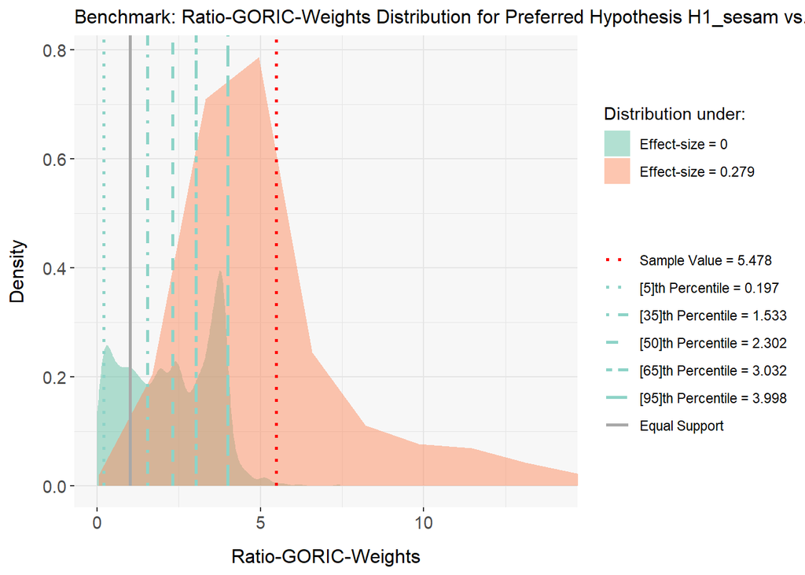

```r
#plot(benchmarks_sesam) # use in R file
Bench.plot <- plot(benchmarks_sesam, x_lim = c(0, 14)) # use in Rmd file
```

One can see, from ‘Error probability Preferred Hypothesis vs. complement’, that there is a 15.4% change that ‘H1_sesam’ is not the correct hypothesis.

From the output, we can also see that our finding is very extreme under the null, since our sample value is higher than the 95th percentile under the null. Hence, there is tremendous support for ‘H1_sesam’ (cf. ‘Guidelines_GORIC-benchmarks’).